# EkinHW2RMarkdown

Ekin Özgürbüz

1 Kasım 2019

# Ekin Özgürbüz HW2

install.packages(“data.table”) install.packages(“lubridate”) install.packages(“ggplot2”) install.packages(“plotly”) install.packages(“dplyr”) install.packages(“caret”) install.packages(“factoextra”) install.packages(“mlbench”) install.packages(“gridExtra”) install.packages(“devtools”) install.packages(“plot3D”) install.packages(“imager”) install.packages(“jpeg”)

```r
library(data.table)
```

```r
library(plot3D)
library(lubridate)
library(ggplot2)
library(plotly)
library(dplyr)
library(caret)
library(factoextra)
library(imager)
library(jpeg)
library(grid)
getwd()
```

```
## [1] "C:/Users/Ekin/Desktop/Ders/0.Master/IE582/Homework 2/HW2Ekin"
```

# Question 1

## Part 1a

### PCA

```r
muskdata = fread("Musk1.csv")
scaledmuskdata = scale(muskdata[,3:168])
musk= cbind(scaledmuskdata,muskdata[,1:2])

length(findCorrelation(cor(musk), cutoff = 0.95,verbose=FALSE)) / ncol(musk)
```

```
## [1] 0.2380952
```

%23 of the attributes are highly correlated, more than 95%. These data can be excluded in order to have a meaningful PCA.

```r
pcamusk = princomp(musk[,1:166], cor=TRUE)
```

In fact, princomp includes scaling. Information about the components can be found by summary function.

```r
summary(pcamusk)
```

```
## Importance of components:
##                           Comp.1    Comp.2     Comp.3     Comp.4
## Standard deviation     7.1952962 4.8073270 3.55611062 2.92188858
## Proportion of Variance 0.3118813 0.1392192 0.07618026 0.05143032
## Cumulative Proportion  0.3118813 0.4511005 0.52728074 0.57871106
##                            Comp.5     Comp.6     Comp.7     Comp.8
## Standard deviation     2.85773479 2.60187102 2.32140301 2.24739135
## Proportion of Variance 0.04919668 0.04078152 0.03246332 0.03042631
## Cumulative Proportion  0.62790774 0.66868926 0.70115258 0.73157890
##                            Comp.9   Comp.10    Comp.11    Comp.12
## Standard deviation     1.81831818 1.6883284 1.60356201 1.54166966
## Proportion of Variance 0.01991736 0.0171714 0.01549043 0.01431774
## Cumulative Proportion  0.75149625 0.7686677 0.78415808 0.79847583
##                           Comp.13    Comp.14    Comp.15     Comp.16
## Standard deviation     1.48576123 1.45214413 1.34646825 1.287366949
## Proportion of Variance 0.01329811 0.01270315 0.01092155 0.009983817
## Cumulative Proportion  0.81177394 0.82447709 0.83539863 0.845382449
##                            Comp.17    Comp.18     Comp.19     Comp.20
## Standard deviation     1.198867064 1.16425207 1.120779718 1.088686243
## Proportion of Variance 0.008658327 0.00816556 0.007567152 0.007139986
## Cumulative Proportion  0.854040776 0.86220634 0.869773487 0.876913474
##                            Comp.21     Comp.22     Comp.23     Comp.24
## Standard deviation     1.059036168 1.028281996 1.024267645 0.984423152
## Proportion of Variance 0.006756371 0.006369662 0.006320025 0.005837885
## Cumulative Proportion  0.883669845 0.890039506 0.896359532 0.902197417
##                            Comp.25     Comp.26     Comp.27    Comp.28
## Standard deviation     0.963374440 0.931918746 0.906238743 0.90125539
## Proportion of Variance 0.005590905 0.005231762 0.004947402 0.00489314
## Cumulative Proportion  0.907788323 0.913020085 0.917967486 0.92286063
##                            Comp.29   Comp.30     Comp.31     Comp.32
## Standard deviation     0.880448192 0.8575237 0.815660682 0.814106578
## Proportion of Variance 0.004669813 0.0044298 0.004007845 0.003992587
## Cumulative Proportion  0.927530440 0.9319602 0.935968086 0.939960673
##                            Comp.33     Comp.34     Comp.35     Comp.36
## Standard deviation     0.798884086 0.742943908 0.698012220 0.686432485
## Proportion of Variance 0.003844673 0.003325094 0.002935067 0.002838491
## Cumulative Proportion  0.943805347 0.947130441 0.950065508 0.952903999
##                            Comp.37     Comp.38     Comp.39     Comp.40
## Standard deviation     0.665185099 0.648668264 0.635554991 0.583645142
## Proportion of Variance 0.002665489 0.002534762 0.002433314 0.002052058
```

[output cut: 114 more lines]

```
## Standard deviation     2.770722e-02 2.744757e-02 2.486674e-02 2.425587e-02
## Proportion of Variance 4.624640e-06 4.538368e-06 3.725030e-06 3.544262e-06
## Cumulative Proportion  9.999685e-01 9.999730e-01 9.999767e-01 9.999803e-01
##                            Comp.157     Comp.158     Comp.159     Comp.160
## Standard deviation     2.340146e-02 2.283557e-02 2.090035e-02 1.933924e-02
## Proportion of Variance 3.298965e-06 3.141345e-06 2.631473e-06 2.253049e-06
## Cumulative Proportion  9.999836e-01 9.999867e-01 9.999894e-01 9.999916e-01
##                            Comp.161     Comp.162     Comp.163     Comp.164
## Standard deviation     1.786650e-02 1.723168e-02 1.670496e-02 1.411429e-02
## Proportion of Variance 1.922963e-06 1.788739e-06 1.681059e-06 1.200080e-06
## Cumulative Proportion  9.999935e-01 9.999953e-01 9.999970e-01 9.999982e-01
##                            Comp.165     Comp.166
## Standard deviation     1.332020e-02 1.100445e-02
## Proportion of Variance 1.068842e-06 7.295055e-07
## Cumulative Proportion  9.999993e-01 1.000000e+00
```

```r
eigenvalues=get_eigenvalue(pcamusk)
head(eigenvalues,10)
```

```
##        eigenvalue variance.percent cumulative.variance.percent
## Dim.1   51.772288        31.188125                    31.18813
## Dim.2   23.110393        13.921923                    45.11005
## Dim.3   12.645923         7.618026                    52.72807
## Dim.4    8.537433         5.143032                    57.87111
## Dim.5    8.166648         4.919668                    62.79077
## Dim.6    6.769733         4.078152                    66.86893
## Dim.7    5.388912         3.246332                    70.11526
## Dim.8    5.050768         3.042631                    73.15789
## Dim.9    3.306281         1.991736                    75.14963
## Dim.10   2.850453         1.717140                    76.86677
```

First 7 elements of the dimensions are contributed %70 of the total variance. (Rule of thumb)

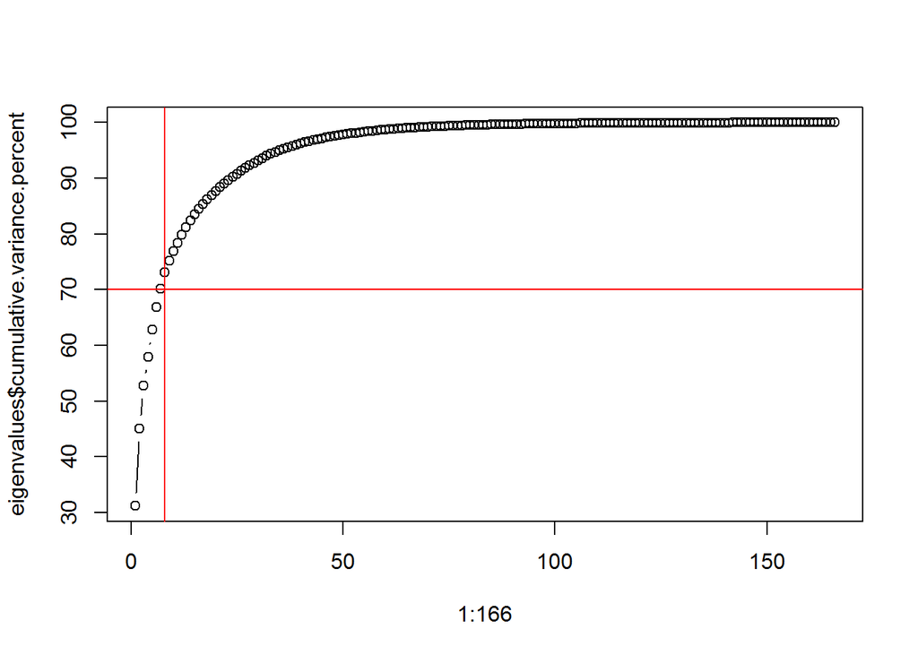

```r
plot(eigenvalues$cumulative.variance.percent,x=1:166,type="b")
abline(v=8, col="red")
abline(h=70,col="red")
```

Visualization of first two components and first three components are visualized below.

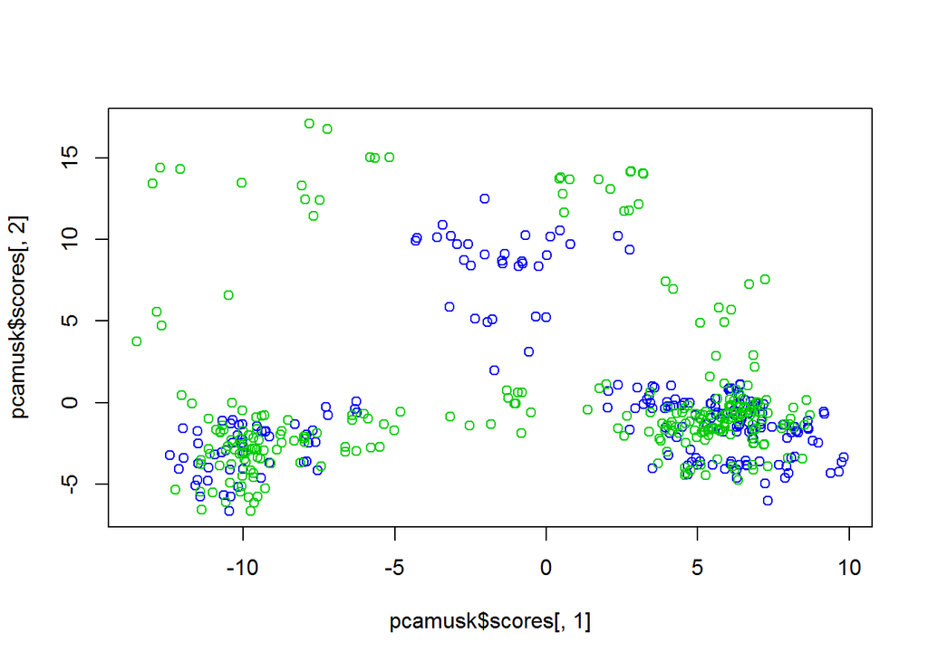

```r
plot(pcamusk$scores[,1],pcamusk$scores[,2],col=musk$V1+3)
```

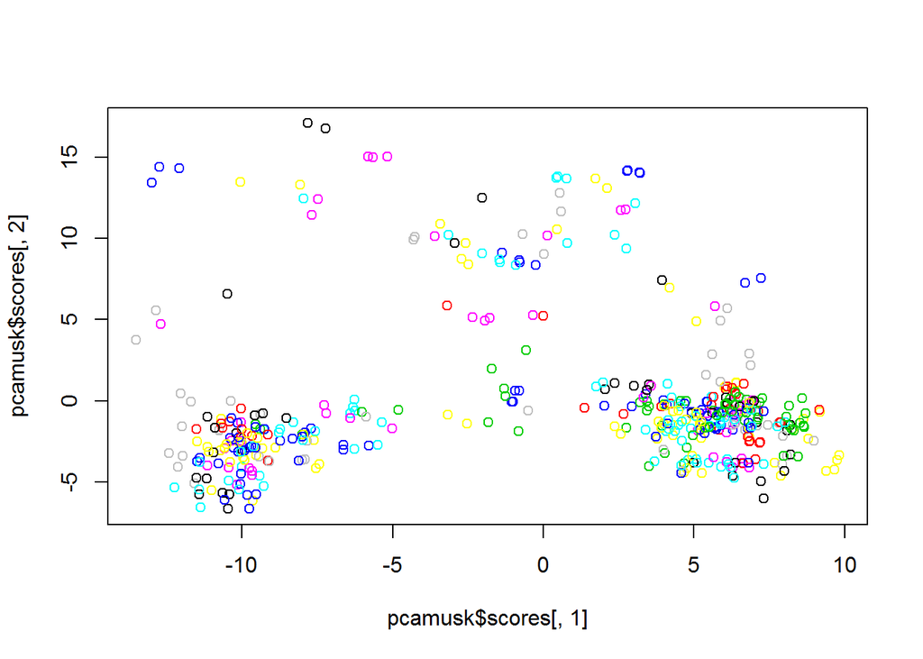

```r
plot(pcamusk$scores[,1],pcamusk$scores[,2],col=musk$V2+3)
```

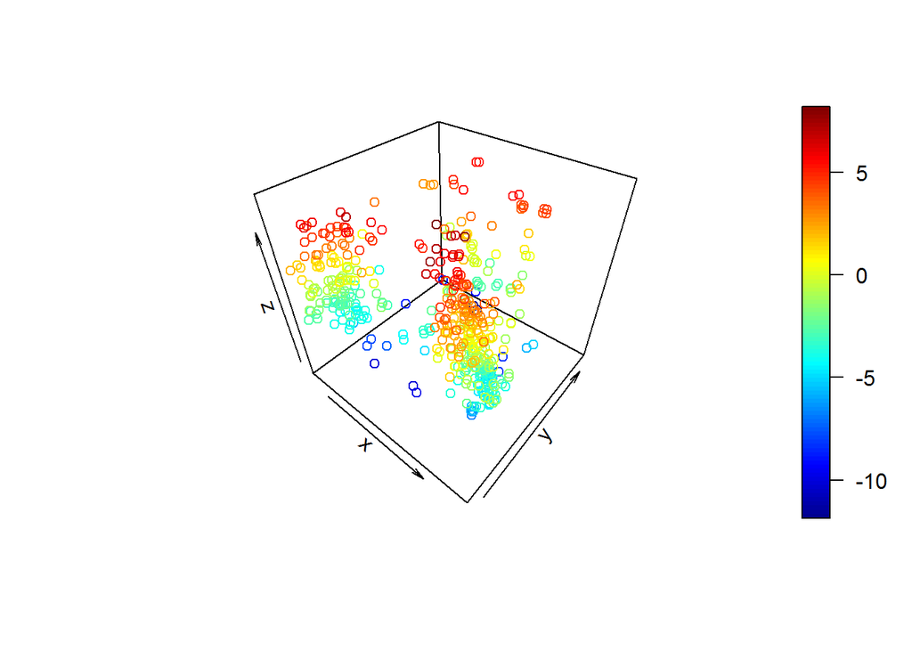

```r
scatter3D(pcamusk$scores[,1], pcamusk$scores[,2], pcamusk$scores[,3])
```

As seen from the graphs above, first 2 and first 3 components are not enough to differentiate Bag classes. Both bag classes are spread through the graph. It is recommended to use 7 components.

### MDS

```r
DistanceMatrix = as.data.table(as.matrix(dist(scaledmuskdata, method = "euclidean")))
mdsmusk = cmdscale(DistanceMatrix, k = 2)
```

k=3 could also be used.

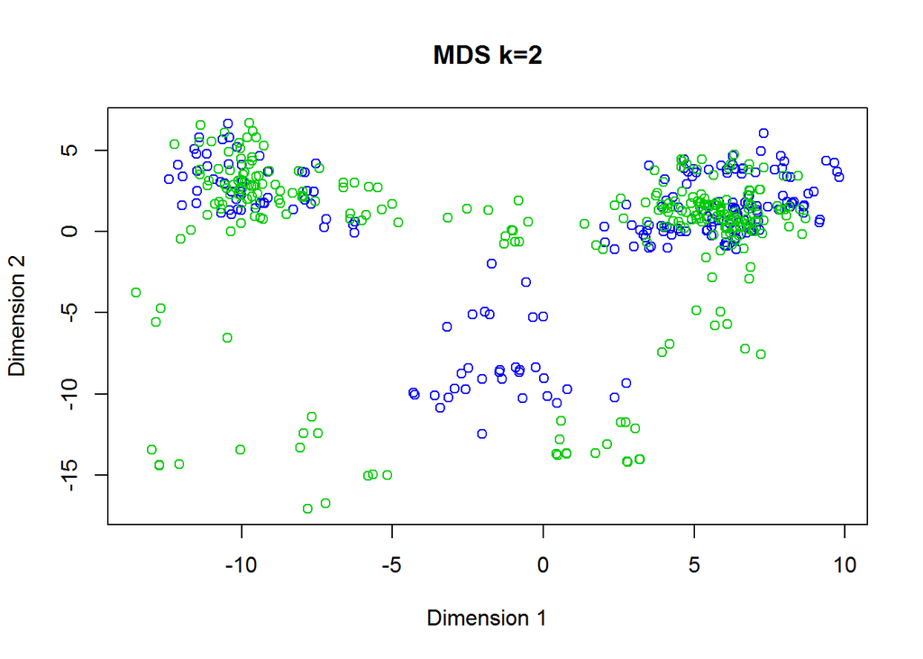

```r
mdsmusklast = cbind(mdsmusk,musk[,1:2])
x= data.frame(mdsmusklast[,1],mdsmusklast[,2])
plot(x, xlab="Dimension 1", ylab="Dimension 2",col= musk$V1+3, main="MDS k=2")
```

MDS results in same manner, there is not a significant differentiability. Both bag classes are spread into graph. Moreover, if k=3 MDS is conducted and evaluated, same result will be observed. MDS and PCA resulted in poor conclusions, due to the reason that 2 dimensions are not capable of explaining at least 80% of the variance.

## Part 1b

We should aggregate Musk data with respect to Bag IDs.

```r
aggregatedmusk = aggregate(muskdata, by = list(muskdata$V2), FUN = mean)
aggregatedmusk = as.data.table(aggregatedmusk)
aggregatedmusk[,Group.1:=NULL]
#aggregatedmusk
scaledmuskdata2 = scale(aggregatedmusk[,3:168])
musk2= cbind(scaledmuskdata2,aggregatedmusk[,1:2])
#musk2
```

### PCA

```r
pcamusk2 = prcomp(musk2[,1:166])
eigenvalues2=get_eigenvalue(pcamusk2)
summary(pcamusk2)
```

```
## Importance of components:
##                           PC1    PC2    PC3    PC4     PC5     PC6     PC7
## Standard deviation     6.6528 5.6257 4.6908 4.2063 3.10049 2.75154 2.24499
## Proportion of Variance 0.2666 0.1907 0.1326 0.1066 0.05791 0.04561 0.03036
## Cumulative Proportion  0.2666 0.4573 0.5898 0.6964 0.75433 0.79993 0.83030
##                            PC8     PC9    PC10    PC11    PC12   PC13
## Standard deviation     1.88542 1.80613 1.60162 1.41639 1.29688 1.2561
## Proportion of Variance 0.02141 0.01965 0.01545 0.01209 0.01013 0.0095
## Cumulative Proportion  0.85171 0.87136 0.88681 0.89890 0.90903 0.9185
##                           PC14    PC15    PC16    PC17    PC18    PC19
## Standard deviation     1.23131 1.05946 1.02942 0.93512 0.91230 0.86691
## Proportion of Variance 0.00913 0.00676 0.00638 0.00527 0.00501 0.00453
## Cumulative Proportion  0.92767 0.93443 0.94081 0.94608 0.95110 0.95562
##                           PC20    PC21    PC22   PC23    PC24    PC25
## Standard deviation     0.79297 0.78039 0.74704 0.6937 0.65812 0.63570
## Proportion of Variance 0.00379 0.00367 0.00336 0.0029 0.00261 0.00243
## Cumulative Proportion  0.95941 0.96308 0.96644 0.9693 0.97195 0.97438
##                           PC26    PC27    PC28   PC29    PC30    PC31
## Standard deviation     0.62054 0.56340 0.53876 0.5149 0.50515 0.48016
## Proportion of Variance 0.00232 0.00191 0.00175 0.0016 0.00154 0.00139
## Cumulative Proportion  0.97670 0.97862 0.98036 0.9820 0.98350 0.98489
##                           PC32    PC33    PC34    PC35    PC36    PC37
## Standard deviation     0.46820 0.44470 0.42894 0.40874 0.39965 0.38054
## Proportion of Variance 0.00132 0.00119 0.00111 0.00101 0.00096 0.00087
## Cumulative Proportion  0.98621 0.98740 0.98851 0.98951 0.99048 0.99135
##                          PC38    PC39    PC40    PC41    PC42    PC43
## Standard deviation     0.3643 0.36024 0.32250 0.31709 0.29101 0.28987
## Proportion of Variance 0.0008 0.00078 0.00063 0.00061 0.00051 0.00051
## Cumulative Proportion  0.9921 0.99293 0.99356 0.99416 0.99467 0.99518
##                           PC44   PC45    PC46    PC47    PC48    PC49
## Standard deviation     0.27843 0.2579 0.25075 0.22941 0.21491 0.21031
## Proportion of Variance 0.00047 0.0004 0.00038 0.00032 0.00028 0.00027
## Cumulative Proportion  0.99565 0.9960 0.99643 0.99674 0.99702 0.99729
##                           PC50    PC51    PC52   PC53    PC54    PC55
## Standard deviation     0.19940 0.19567 0.18698 0.1828 0.17357 0.16440
## Proportion of Variance 0.00024 0.00023 0.00021 0.0002 0.00018 0.00016
## Cumulative Proportion  0.99753 0.99776 0.99797 0.9982 0.99835 0.99851
##                           PC56    PC57    PC58    PC59   PC60    PC61
## Standard deviation     0.15556 0.15071 0.14823 0.13348 0.1277 0.12491
## Proportion of Variance 0.00015 0.00014 0.00013 0.00011 0.0001 0.00009
```

[output cut: 10 more lines]

```
## Standard deviation     0.06194 0.06145 0.05420 0.05184 0.04933 0.04641
## Proportion of Variance 0.00002 0.00002 0.00002 0.00002 0.00001 0.00001
## Cumulative Proportion  0.99984 0.99987 0.99988 0.99990 0.99992 0.99993
##                           PC80    PC81    PC82    PC83    PC84    PC85
## Standard deviation     0.04430 0.04222 0.04009 0.03499 0.03489 0.03129
## Proportion of Variance 0.00001 0.00001 0.00001 0.00001 0.00001 0.00001
## Cumulative Proportion  0.99994 0.99995 0.99996 0.99997 0.99998 0.99998
##                           PC86    PC87    PC88    PC89   PC90    PC91
## Standard deviation     0.02695 0.02536 0.02481 0.02177 0.0201 0.01676
## Proportion of Variance 0.00000 0.00000 0.00000 0.00000 0.0000 0.00000
## Cumulative Proportion  0.99999 0.99999 0.99999 1.00000 1.0000 1.00000
##                             PC92
## Standard deviation     4.665e-16
## Proportion of Variance 0.000e+00
## Cumulative Proportion  1.000e+00
```

```r
head(eigenvalues2,10)
```

```
##        eigenvalue variance.percent cumulative.variance.percent
## Dim.1   44.259394        26.662286                    26.66229
## Dim.2   31.648905        19.065605                    45.72789
## Dim.3   22.003348        13.255029                    58.98292
## Dim.4   17.693363        10.658653                    69.64157
## Dim.5    9.613045         5.790991                    75.43256
## Dim.6    7.570992         4.560838                    79.99340
## Dim.7    5.039994         3.036141                    83.02954
## Dim.8    3.554791         2.141441                    85.17098
## Dim.9    3.262093         1.965116                    87.13610
## Dim.10   2.565192         1.545296                    88.68140
```

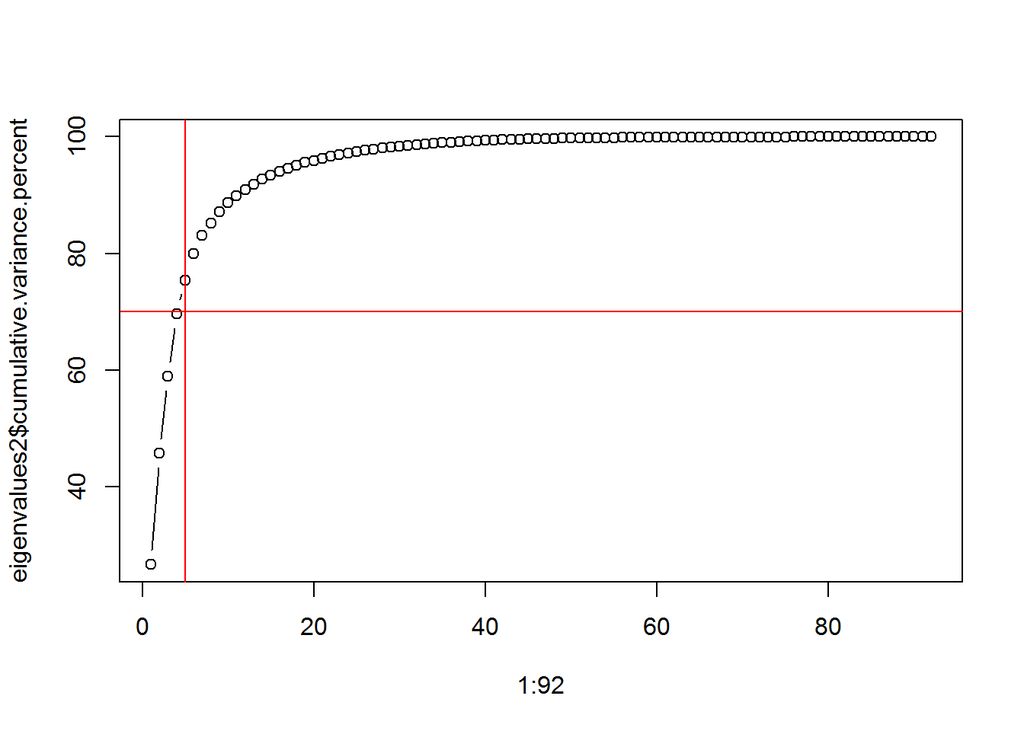

```r
plot(eigenvalues2$cumulative.variance.percent,x=1:92,type="b")
abline(v=5, col="red")
abline(h=70,col="red")
```

### MDS

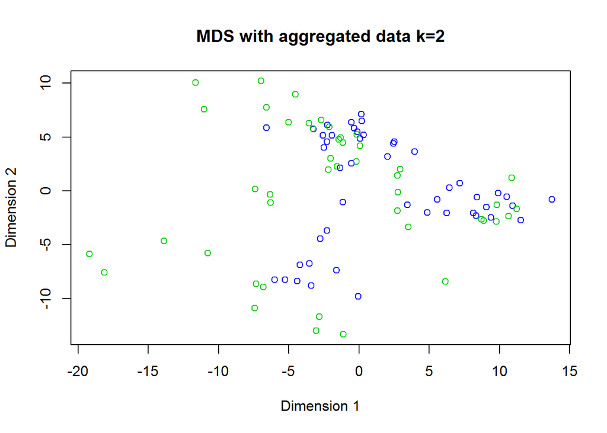

```r
DistanceMatrix2 = as.data.table(as.matrix(dist(scaledmuskdata2, method = "euclidean")))
mdsmusk2 = cmdscale(DistanceMatrix2, k = 2)
#k=3 could also be used.
mdsmusklast2 = cbind(mdsmusk2,musk2[,1:2])
x2= data.frame(mdsmusklast2[,1],mdsmusklast2[,2])
plot(x2, xlab="Dimension 1", ylab="Dimension 2",col= musk2$V1 + 3, main="MDS with aggregated data k=2")
```

Results of aggregated PCA and MDS is very similar to previous graphs. On the other hand, grouping instances seems to be more logical since difference between bags are more clear.

# Question 2

## Part 2a

```r
dev.off()
```

```r
ataturklisesi = load.image("C:/Users/Ekin/Desktop/AnkaraAtaturkLisesi.jpg")
str(ataturklisesi)
```

```
##  cimg [1:256, 1:256, 1, 1:3] 0.69 0.698 0.702 0.698 0.698 ...
```

```r
plot(c(1, 256), c(1, 256), type = "n", xlab = "", ylab = "",main = "Türkiye'nin en iyi lisesi")
rasterImage(ataturklisesi, 1, 1, 256, 256)
```

[output not shown]

## Part 2b

[figure not shown]

```r
ataturklisesired = copy(ataturklisesi)
ataturklisesiblue = copy(ataturklisesi)
ataturklisesigreen = copy(ataturklisesi)

B(ataturklisesired) = 0
G(ataturklisesired) = 0
R(ataturklisesiblue) = 0
G(ataturklisesiblue) = 0
R(ataturklisesigreen) = 0
B(ataturklisesigreen) = 0

par(mfrow = c(1,3))
plot(c(1, 256), c(1, 256), type = "n", xlab = "", ylab = "", main = "Red")
rasterImage(ataturklisesired, 0, 0, 256, 256, angle = 0, interpolate = FALSE)
plot(c(1, 256), c(1, 256), type = "n", xlab = "", ylab = "", main = "Green")
rasterImage(ataturklisesigreen, 0, 0, 256, 256, angle = 0, interpolate = FALSE)
plot(c(1, 256), c(1, 256), type = "n", xlab = "", ylab = "", main = "Blue")
rasterImage(ataturklisesiblue, 0, 0, 256, 256, angle = 0, interpolate = FALSE)
```

[figure not shown]

```r
minimal = min(ataturklisesi)
maximal = max(ataturklisesi)*0.1
Noise1=matrix(runif(65536,min=minimal,max=maximal),256)
Noise2=matrix(runif(65536,min=minimal,max=maximal),256)
Noise3=matrix(runif(65536,min=minimal,max=maximal),256)

ataturklisesinoise = ataturklisesi

ataturklisesinoise[,,1] <- ataturklisesi[,,1] + Noise1
ataturklisesinoise [,,2] <- ataturklisesi [,,2] + Noise2
ataturklisesinoise [,,3] <- ataturklisesi [,,3] + Noise3

ataturklisesinoise [,,1][ataturklisesinoise [,,1]>1]=1
ataturklisesinoise [,,2][ataturklisesinoise [,,2]>1]=1
ataturklisesinoise [,,3][ataturklisesinoise [,,3]>1]=1

par(mfrow = c(1,2))
plot(c(1, 256), c(1, 256), axes = FALSE, col = 0, xlab = "",ylab = "", main = "Noised image")
rasterImage(ataturklisesinoise, 0,0,256,256, interpolate = FALSE)
plot(c(1, 256), c(1, 256), axes = FALSE ,xlab = "",ylab = "", col = 0, main = "Original image ")
rasterImage(ataturklisesi, 0,0,256,256, interpolate = FALSE)
```

```r
ataturklisesinoisered = copy(ataturklisesinoise)
ataturklisesinoiseblue = copy(ataturklisesinoise)
ataturklisesinoisegreen = copy(ataturklisesinoise)

B(ataturklisesinoisered) = 0
G(ataturklisesinoisered) = 0
R(ataturklisesinoiseblue) = 0
G(ataturklisesinoiseblue) = 0
R(ataturklisesinoisegreen) = 0
B(ataturklisesinoisegreen) = 0
```

Displaying each channel of noised image

[figure not shown]

```r
par(mfrow = c(1, 4))
plot(c(1, 256), c(1, 256),type = "n", xlab = "", ylab = "",main = "Noised image")
rasterImage(ataturklisesinoise, 0,0,256,256, interpolate = FALSE)
plot(c(1, 256), c(1, 256), type = "n", xlab = "", ylab = "", main = "Red")
rasterImage(ataturklisesinoisered, 0, 0, 256, 256, angle = 0, interpolate = FALSE)
plot(c(1, 256), c(1, 256), type = "n", xlab = "", ylab = "", main = "Green")
rasterImage(ataturklisesinoisegreen, 0, 0, 256, 256, angle = 0, interpolate = FALSE)
plot(c(1, 256), c(1, 256), type = "n", xlab = "", ylab = "", main = "Blue")
rasterImage(ataturklisesinoiseblue, 0, 0, 256, 256, angle = 0, interpolate = FALSE)
```

### Part 2c

```r
dev.off()
```

```r
ataturklisesigray = imager::grayscale(ataturklisesinoise)
plot(c(1, 256), c(1, 256), type = "n", xlab = "", ylab = "", main = "Atatürk Lisesi Noised Gray")
rasterImage(ataturklisesigray, 1, 1, 256, 256, angle = 0, interpolate = FALSE)
```

[output not shown]

It is desired to use 25x25 sized patches. Now we have 625 instances. Therefore, there will be (256-25+1) x (256-25+1) many patches. +1 comes from the initial matrix created. -25 comes from the length of the patches. Simple math.

```r
DataMatrix = matrix(, nrow = 232 * 232, ncol = 25*25)
```

Since for loop first increases j, the matrix is filled with data from left to right first, then i increases and matrix goes below through y axis.

```r
k = 1
for (i in 13:244) {
  for (j in 13:244) {
    featurevector = ataturklisesigray[(i - 12):(i + 12),(j - 12):(j + 12) ]
    featurevector = as.vector(featurevector)
    DataMatrix[k, ] = featurevector
    k = k + 1
  }
}
```

### Part 2c-a

```r
ataturklisesigraypca = princomp(DataMatrix)
summary(ataturklisesigraypca)
```

```
## Importance of components:
##                           Comp.1    Comp.2     Comp.3     Comp.4
## Standard deviation     4.8345509 2.0062689 1.05824091 0.81117244
## Proportion of Variance 0.6167328 0.1062094 0.02954975 0.01736245
## Cumulative Proportion  0.6167328 0.7229422 0.75249192 0.76985438
##                            Comp.5     Comp.6     Comp.7     Comp.8
## Standard deviation     0.78496015 0.76612837 0.70778548 0.65660686
## Proportion of Variance 0.01625848 0.01548773 0.01321868 0.01137616
## Cumulative Proportion  0.78611286 0.80160059 0.81481927 0.82619542
##                             Comp.9    Comp.10     Comp.11     Comp.12
## Standard deviation     0.535238377 0.51755684 0.512260897 0.464750725
## Proportion of Variance 0.007559259 0.00706807 0.006924161 0.005699344
## Cumulative Proportion  0.833754683 0.84082275 0.847746915 0.853446259
##                            Comp.13     Comp.14     Comp.15     Comp.16
## Standard deviation     0.450939936 0.442365076 0.436222669 0.418705217
## Proportion of Variance 0.005365648 0.005163526 0.005021127 0.004625956
## Cumulative Proportion  0.858811906 0.863975433 0.868996560 0.873622516
##                            Comp.17     Comp.18     Comp.19    Comp.20
## Standard deviation     0.396857476 0.392174171 0.386135395 0.37642695
## Proportion of Variance 0.004155793 0.004058287 0.003934268 0.00373892
## Cumulative Proportion  0.877778309 0.881836595 0.885770863 0.88950978
##                            Comp.21     Comp.22     Comp.23     Comp.24
## Standard deviation     0.363743598 0.353594190 0.342018274 0.330404756
## Proportion of Variance 0.003491206 0.003299096 0.003086621 0.002880563
## Cumulative Proportion  0.893000989 0.896300085 0.899386707 0.902267270
##                           Comp.25     Comp.26     Comp.27     Comp.28
## Standard deviation     0.32172761 0.318540855 0.317130342 0.311040984
## Proportion of Variance 0.00273125 0.002677411 0.002653752 0.002552819
## Cumulative Proportion  0.90499852 0.907675930 0.910329682 0.912882501
##                            Comp.29     Comp.30     Comp.31     Comp.32
## Standard deviation     0.293048141 0.290185784 0.277923231 0.275911833
## Proportion of Variance 0.002266015 0.002221964 0.002038142 0.002008748
## Cumulative Proportion  0.915148515 0.917370479 0.919408621 0.921417369
##                            Comp.33     Comp.34     Comp.35     Comp.36
## Standard deviation     0.272231280 0.270400316 0.258677455 0.254824074
## Proportion of Variance 0.001955513 0.001929297 0.001765639 0.001713427
## Cumulative Proportion  0.923372883 0.925302180 0.927067819 0.928781246
##                            Comp.37     Comp.38     Comp.39     Comp.40
## Standard deviation     0.252119698 0.250880857 0.248568728 0.242663057
## Proportion of Variance 0.001677252 0.001660809 0.001630338 0.001553789
```

[output cut: 574 more lines]

```
## Standard deviation     1.876780e-02 1.875487e-02 1.874753e-02 1.859155e-02
## Proportion of Variance 9.294190e-06 9.281391e-06 9.274119e-06 9.120441e-06
## Cumulative Proportion  9.998939e-01 9.999032e-01 9.999124e-01 9.999215e-01
##                            Comp.617     Comp.618     Comp.619     Comp.620
## Standard deviation     1.856691e-02 1.847891e-02 1.841314e-02 1.829248e-02
## Proportion of Variance 9.096283e-06 9.010265e-06 8.946235e-06 8.829372e-06
## Cumulative Proportion  9.999306e-01 9.999397e-01 9.999486e-01 9.999574e-01
##                            Comp.621     Comp.622     Comp.623     Comp.624
## Standard deviation     1.828321e-02 1.799899e-02 1.798227e-02 1.779003e-02
## Proportion of Variance 8.820426e-06 8.548327e-06 8.532447e-06 8.350996e-06
## Cumulative Proportion  9.999663e-01 9.999748e-01 9.999833e-01 9.999917e-01
##                            Comp.625
## Standard deviation     1.775243e-02
## Proportion of Variance 8.315733e-06
## Cumulative Proportion  1.000000e+00
```

```r
eigenvalues2=get_eigenvalue(ataturklisesigraypca)
head(eigenvalues2,10)
```

```
##        eigenvalue variance.percent cumulative.variance.percent
## Dim.1  23.3728821       61.6732753                    61.67328
## Dim.2   4.0251148       10.6209416                    72.29422
## Dim.3   1.1198738        2.9549752                    75.24919
## Dim.4   0.6580007        1.7362455                    76.98544
## Dim.5   0.6161624        1.6258481                    78.61129
## Dim.6   0.5869527        1.5487732                    80.16006
## Dim.7   0.5009603        1.3218679                    81.48193
## Dim.8   0.4311326        1.1376157                    82.61954
## Dim.9   0.2864801        0.7559259                    83.37547
## Dim.10  0.2678651        0.7068070                    84.08228
```

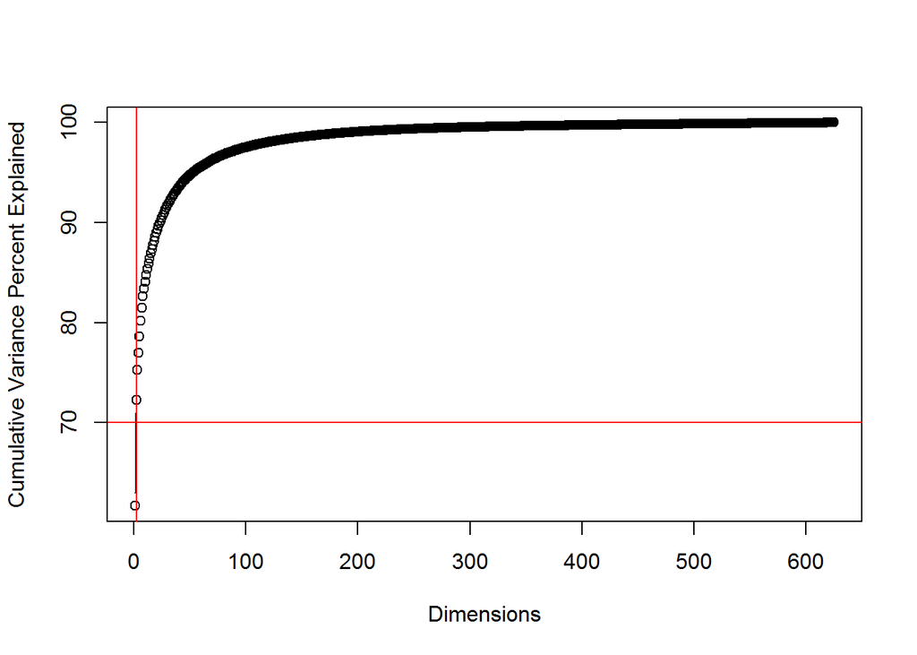

```r
plot(eigenvalues2$cumulative.variance.percent,x=1:625,type="b",xlab="Dimensions",ylab="Cumulative Variance Percent Explained")
abline(v=2, col="red")
abline(h=70,col="red")
```

### Part 2c-b

```r
Scoresofpca = as.data.table(ataturklisesigraypca$scores)
head(Scoresofpca)
```

```
##       Comp.1     Comp.2    Comp.3      Comp.4     Comp.5      Comp.6
## 1: -5.277061 -0.1919231 0.2890450  0.01843937 0.08393426 -0.01803642
## 2: -5.273129 -0.2019084 0.2794180 -0.00793923 0.07863112 -0.02231589
## 3: -5.271884 -0.2194275 0.2723272 -0.04357425 0.07427631 -0.02137407
## 4: -5.272128 -0.2179304 0.2655695 -0.06130920 0.08028916 -0.02571258
## 5: -5.281213 -0.2103111 0.2700921 -0.06996370 0.09809206 -0.02287956
## 6: -5.242516 -0.2698181 0.2088768 -0.12072340 0.07639631 -0.04321489
##          Comp.7       Comp.8      Comp.9    Comp.10     Comp.11
## 1: -0.007207983 -0.017888981 0.003788091 -0.1275419 0.017149572
## 2: -0.012492962  0.011998895 0.015281872 -0.1176170 0.014091737
## 3: -0.014464069  0.019416217 0.029531306 -0.1091868 0.009069985
## 4: -0.016053085  0.007992377 0.061836699 -0.1039060 0.005239495
## 5: -0.029261157 -0.024724801 0.085042046 -0.1134140 0.016292962
## 6: -0.025818757 -0.022883115 0.029839204 -0.1008288 0.009795682
##        Comp.12      Comp.13     Comp.14     Comp.15       Comp.16
```

[output cut: 860 more lines]

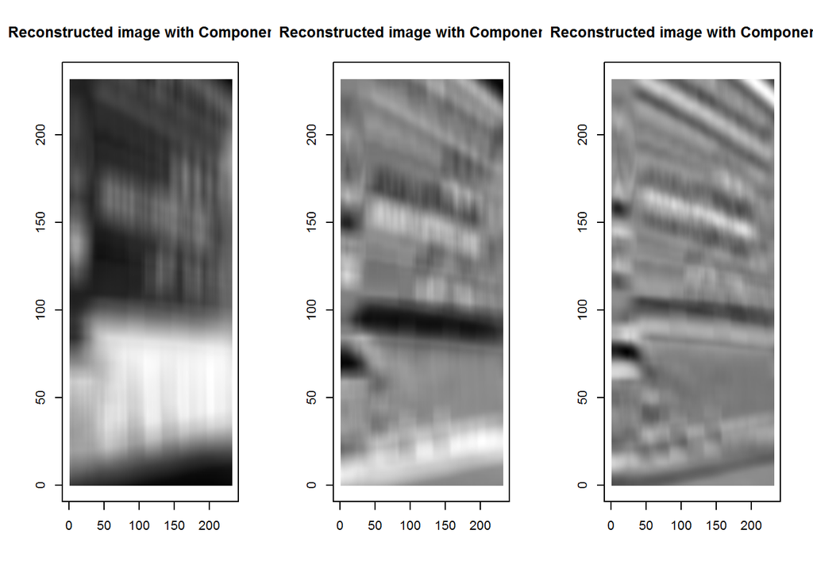

```r
Component1 = matrix(Scoresofpca$Comp.1, nrow = 232, ncol = 232 , byrow = TRUE)
Component2 = matrix(Scoresofpca$Comp.2, nrow = 232, ncol = 232 , byrow = TRUE)
Component3 = matrix(Scoresofpca$Comp.3, nrow = 232, ncol = 232 , byrow = TRUE)

par(mfrow = c(1, 3))
plot(c(0, 232), c(0, 232), type = "n", xlab = "", ylab = "",main = "Reconstructed image with Component 1")
rasterImage(as.cimg(Component1), 0, 0, 232, 232, angle = 0, interpolate = TRUE)
plot(c(0, 232), c(0, 232), type = "n", xlab = "", ylab = "",main = "Reconstructed image with Component 2")
rasterImage(as.cimg(Component2), 0, 0, 232, 232, angle = 0, interpolate = TRUE)
plot(c(0, 232), c(0, 232), type = "n", xlab = "", ylab = "",main = "Reconstructed image with Component 3")
rasterImage(as.cimg(Component3), 0, 0, 232, 232, angle = 0, interpolate = TRUE)
```

First component is holding the variance more than other components. Therefore, as expected, the image reconstructed from component 1 is better than others. Second component is worse than first. Since components are reordered with respect to their contribution to total variance, it is expected to have worse images while proceding into higher index components.

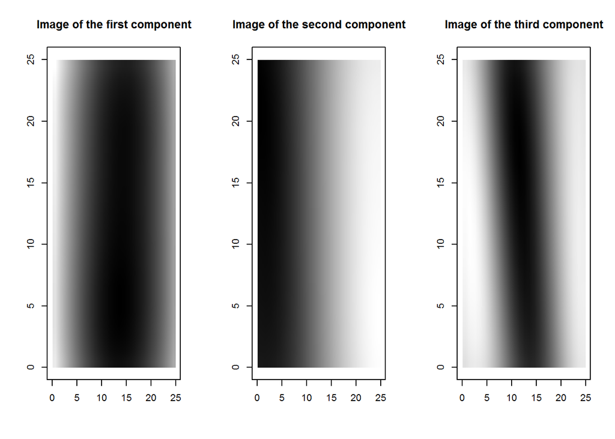

```r
FirstComponent = ataturklisesigraypca$loadings[,1]
FirstComponent = matrix(FirstComponent, nrow = 25, ncol = 25, byrow = TRUE)
SecondComponent = ataturklisesigraypca$loadings[,2]
SecondComponent = matrix(SecondComponent, nrow = 25, ncol = 25, byrow = TRUE)
ThirdComponent = ataturklisesigraypca$loadings[,3]
ThirdComponent = matrix(ThirdComponent, nrow = 25, ncol = 25, byrow = TRUE)

par(mfrow = c(1, 3))

plot(c(0, 25), c(0, 25), type = "n", xlab = "", ylab = "",main = "Image of the first component")
rasterImage(as.cimg(FirstComponent), 0, 0, 25, 25, angle = 0, interpolate = TRUE)
plot(c(0, 25), c(0, 25), type = "n", xlab = "", ylab = "",main = "Image of the second component")
rasterImage(as.cimg(SecondComponent), 0, 0, 25, 25, angle = 0, interpolate = TRUE)
plot(c(0, 25), c(0, 25), type = "n", xlab = "", ylab = "",main = "Image of the third component")
rasterImage(as.cimg(ThirdComponent), 0, 0, 25, 25, angle = 0, interpolate = TRUE)
```

First component seems to explain the building at the center of the image well. As expected, first component resulted better in representing the original image. Second component created image at the left side of the square. Third component is close to first component, however it is more dense near center and less dense across edges of the image through x axis. Combining components may help to reconstruct the image.